# Homework 2 - Asu Naz Yıldırım

```python
import pandas as pd
import numpy as np
import matplotlib.pyplot as plt
from rpy2.robjects import pandas2ri, r
from IPython.display import Image, display
import os
from rpy2.robjects.packages import importr
pandas2ri.activate()
base = importr('base')
rpart = importr('rpart')
rpart_plot = importr('rpart.plot')
rattle = importr("rattle")
grdevices = importr("grDevices")
match_data =pd.read_csv('match_data/match_data.csv')
```

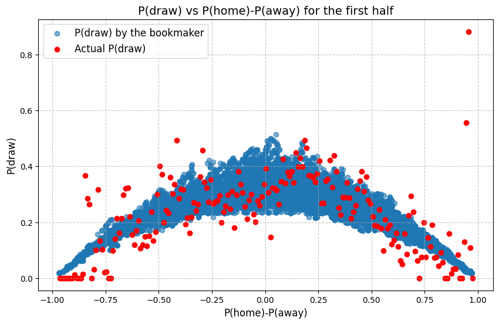

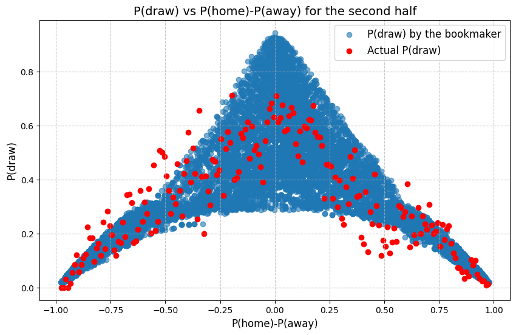

```python
first_half_data = match_data[(match_data['halftime'] == '1st-half') & (match_data['suspended'] == False) & (match_data['stopped'] == False)]
second_half_data = match_data[(match_data['halftime'] == '2nd-half') & (match_data['suspended'] == False) & (match_data['stopped'] == False)]

def calculate_probabilities(df):
    df = df.copy()
    df['P_home'] = 1 / df['1']
    df['P_draw'] = 1 / df['X']
    df['P_away'] = 1 / df['2']
    total = df['P_home'] + df['P_draw'] + df['P_away']
    df['P_home_norm'] = df['P_home'] / total
    df['P_draw_norm'] = df['P_draw'] / total
    df['P_away_norm'] = df['P_away'] / total
    df['P_diff'] = df['P_home_norm'] - df['P_away_norm']
    return df

first_half_processed = calculate_probabilities(first_half_data)
second_half_processed = calculate_probabilities(second_half_data)

def bin_and_calculate_actual(df, bins):
    df['P_diff_bin'] = pd.cut(df['P_diff'], bins)
    total_counts = df.groupby('P_diff_bin')['result'].count()
    draw_counts = df[df['result'] == 'X'].groupby('P_diff_bin')['result'].count()
    actual_prob = draw_counts / total_counts
    return actual_prob

bins = np.arange(-1, 1.1, 0.01)
bin_midpoints = bins[:-1] + (bins[1] - bins[0]) / 2
first_half_actual = bin_and_calculate_actual(first_half_processed, bins)
second_half_actual = bin_and_calculate_actual(second_half_processed, bins)

def plot_draw(df, bin_midpoints, actual):
    actual_values = actual.values
    plt.figure(figsize=(10, 6))
    plt.scatter(df['P_diff'], df['P_draw_norm'], alpha=0.6, label="P(draw) by the bookmaker")
    plt.scatter(bin_midpoints, actual_values, color='red', marker='o', label="Actual P(draw)")
    if df['halftime'].iloc[0] == '1st-half':
        plt.title("P(draw) vs P(home)-P(away) for the first half", fontsize=14)
    else:
        plt.title("P(draw) vs P(home)-P(away) for the second half", fontsize=14)
    plt.xlabel("P(home)-P(away)", fontsize=12)
    plt.ylabel("P(draw)", fontsize=12)
    plt.grid(True, linestyle='--', alpha=0.7)
    plt.legend(fontsize=12)
    plt.show()

plot_draw(first_half_processed,bin_midpoints,first_half_actual)
plot_draw(second_half_processed,bin_midpoints,second_half_actual)
```

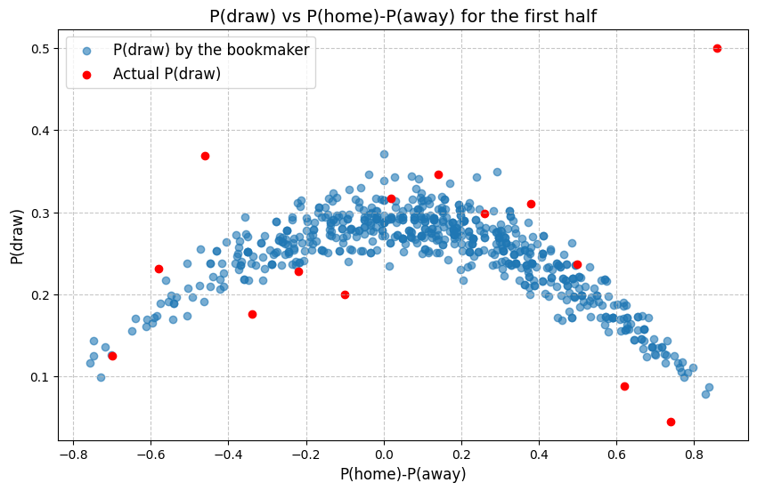

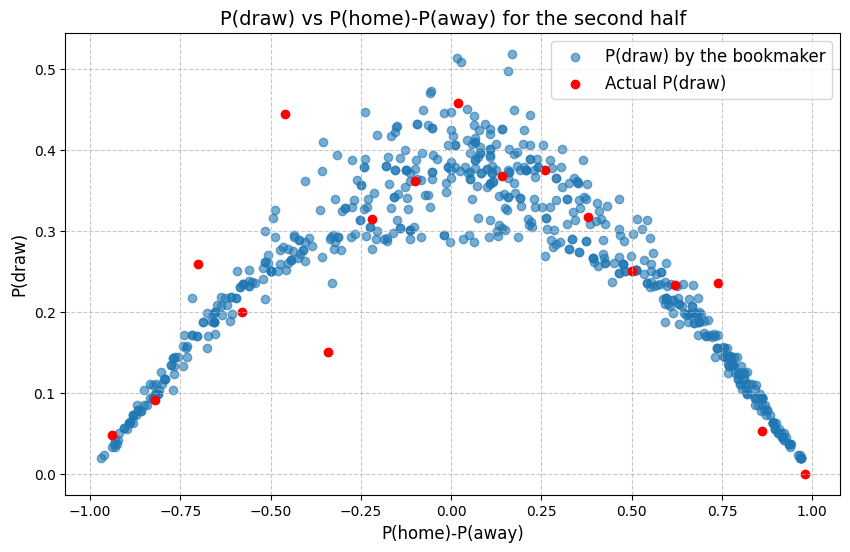

```python
bins = np.arange(-1, 1.1, 0.12)
bin_midpoints = bins[:-1] + (bins[1] - bins[0]) / 2
first_half_data_initial_bet = first_half_data.groupby('fixture_id').first()
second_half_data_initial_bet = second_half_data.groupby('fixture_id').first()
first_half_data_initial_bet_processed = calculate_probabilities(first_half_data_initial_bet)
second_half_data_initial_bet_processed = calculate_probabilities(second_half_data_initial_bet)
first_half_data_initial_bet_actual = bin_and_calculate_actual(first_half_data_initial_bet_processed, bins)
second_half_data_initial_bet_actual = bin_and_calculate_actual(second_half_data_initial_bet_processed, bins)
plot_draw(first_half_data_initial_bet_processed,bin_midpoints,first_half_data_initial_bet_actual)
plot_draw(second_half_data_initial_bet_processed,bin_midpoints,second_half_data_initial_bet_actual)
```

For these plots, I only used the first bet from each game to compare results. Both the first and second half plots (the blue dots) show a pattern similar to what we observed previously. In the first half, the actual probabilities indicated by red points seem to fluctuate compared to blue dots' shape. Red dots either fall outside the bookmaker’s predicted range (blue dots) or at its extremity. This may show the inefficiencies in the P(draw) set by bookmakers. In the second half, although the red dots appear more aligned with the blue dots, some red points still lie outside the bookmakers' predicted range.

```
Number of matches removed due to early red cards: 2
Number of matches removed due to late goal affecting the result: 66
```

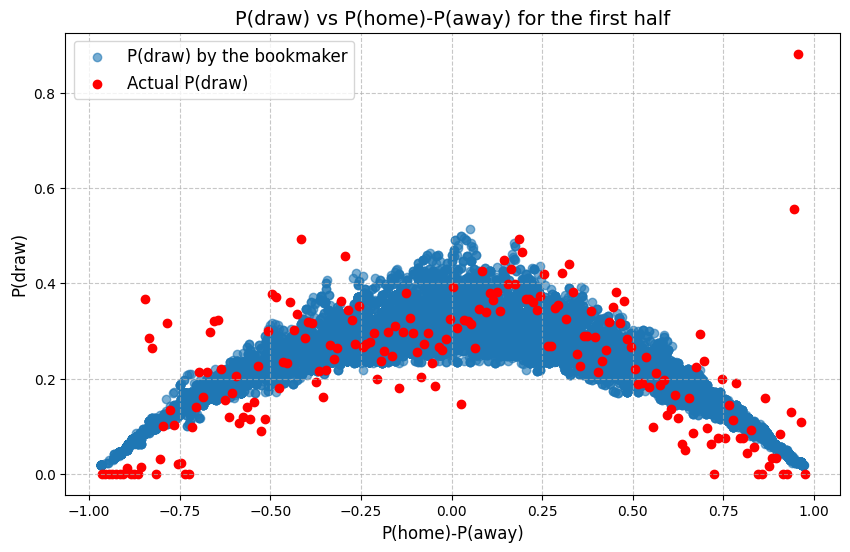

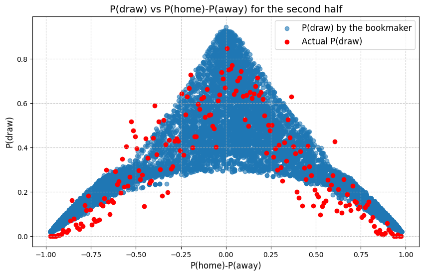

```python
FH_data = match_data[(match_data['halftime'] == '1st-half') & (match_data['suspended'] == False) & (match_data['stopped'] == False)]
matches_with_early_red_cards = FH_data[
    (FH_data['minute'] <= 15) &
    ((FH_data['Redcards - away'] > 0) | (FH_data['Redcards - home'] > 0) | (FH_data['Yellowred Cards - home'] > 0) | (FH_data['Yellowred Cards - away'] > 0) )
]['fixture_id'].unique()
cleaned_FH_data = FH_data[~FH_data['fixture_id'].isin(matches_with_early_red_cards)]
removed_count = len(matches_with_early_red_cards)
print(f"Number of matches removed due to early red cards: {removed_count}")


#Remove matches with late goal affecting the result
SH_data = match_data[(match_data['halftime'] == '2nd-half') & (match_data['suspended'] == False) & (match_data['stopped'] == False)]
late_minute_data = SH_data[SH_data['minute'] >= 45]
matches_to_remove = []
for fixture_id in late_minute_data['fixture_id'].unique():
    match_data = SH_data[SH_data['fixture_id'] == fixture_id]
    state_at_90_plus = match_data[match_data['minute'] >= 45]['current_state'].iloc[0]
    final_result = match_data['result'].iloc[0]
    if state_at_90_plus != final_result:
        matches_to_remove.append(fixture_id)
cleaned_SH_data = SH_data[~SH_data['fixture_id'].isin(matches_to_remove)]
removed_count = len(matches_to_remove)
print(f"Number of matches removed due to late goal affecting the result: {removed_count}")


cleaned_first_half_processed = calculate_probabilities(cleaned_FH_data)
cleaned_second_half_processed = calculate_probabilities(cleaned_SH_data)
cleaned_first_half_actual = bin_and_calculate_actual(cleaned_first_half_processed, bins)
cleaned_second_half_actual = bin_and_calculate_actual(cleaned_second_half_processed, bins)
plot_draw(cleaned_first_half_processed,bin_midpoints,cleaned_first_half_actual)
plot_draw(cleaned_second_half_processed,bin_midpoints,cleaned_second_half_actual)
```

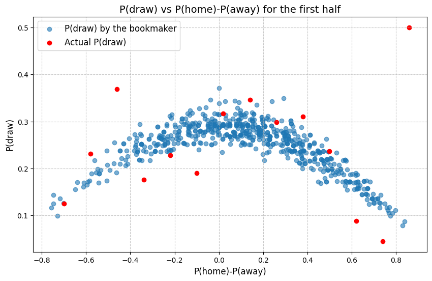

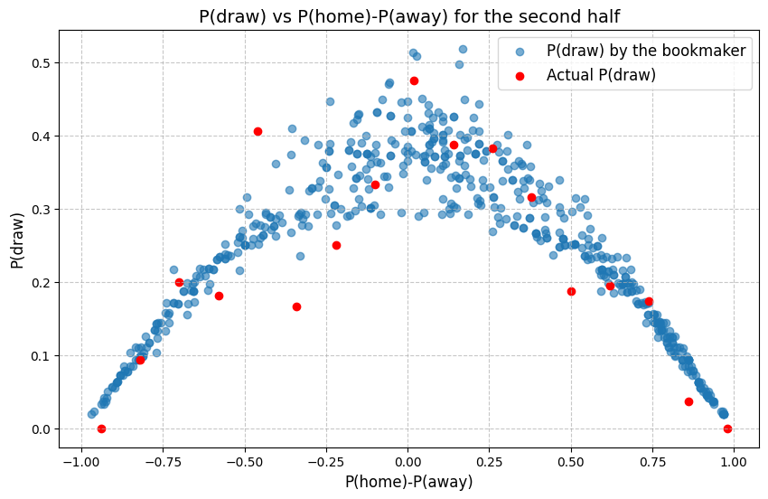

```python
bins = np.arange(-1, 1.1, 0.12)
bin_midpoints = bins[:-1] + (bins[1] - bins[0]) / 2
cleaned_first_half_data_initial_bet = cleaned_FH_data.groupby('fixture_id').first()
cleaned_second_half_data_initial_bet = cleaned_SH_data.groupby('fixture_id').first()
cleaned_first_half_data_initial_bet_processed = calculate_probabilities(cleaned_first_half_data_initial_bet)
cleaned_second_half_data_initial_bet_processed = calculate_probabilities(cleaned_second_half_data_initial_bet)
cleaned_first_half_data_initial_bet_actual = bin_and_calculate_actual(cleaned_first_half_data_initial_bet_processed, bins)
cleaned_second_half_data_initial_bet_actual = bin_and_calculate_actual(cleaned_second_half_data_initial_bet_processed, bins)
plot_draw(cleaned_first_half_data_initial_bet_processed,bin_midpoints,cleaned_first_half_data_initial_bet_actual)
plot_draw(cleaned_second_half_data_initial_bet_processed,bin_midpoints,cleaned_second_half_data_initial_bet_actual)
```

I remove the matches when there is a red card in the first 15 minutes or when there is a late goal affecting the bet result. Total of 68 matches are removed. Since this number is small compared to total number of instances, there is no significant change in the observation.

```python
match_data_tree =match_data[(match_data['suspended'] == False) & (match_data['stopped'] == False)]
match_data_tree.loc[:, 'result'] = match_data_tree['result'].astype('category')
match_data_tree = match_data_tree.copy()
match_data_tree.rename(columns={ '1': 'home_odds', '2': 'away_odds', 'X': 'draw_odds'}, inplace=True)
match_data_tree.columns = match_data_tree.columns.str.replace(r'[^0-9a-zA-Z_]', '_', regex=True)
r_df = pandas2ri.py2rpy(match_data_tree)
column_names = robjects.r("colnames")(r_df)
for col in column_names:
    print(col)
```

```
fixture_id
halftime
current_time
half_start_datetime
match_start_datetime
minute
second
latest_bookmaker_update
suspended
stopped
home_odds
away_odds
draw_odds
name
ticking
Accurate_Crosses___away
Accurate_Crosses___home
Assists___away
Assists___home
Attacks___away
Attacks___home
Ball_Possession_____away
Ball_Possession_____home
Ball_Safe___away
Ball_Safe___home
Challenges___away
Challenges___home
Corners___away
Corners___home
Counter_Attacks___away
Counter_Attacks___home
Dangerous_Attacks___away
Dangerous_Attacks___home
Dribble_Attempts___away
Dribble_Attempts___home
Fouls___away
Fouls___home
Free_Kicks___away
Free_Kicks___home
Goal_Attempts___away
```

[output cut: 51 more lines]

```
Successful_Passes_Percentage___away
Successful_Passes_Percentage___home
Tackles___away
Tackles___home
Throwins___away
Throwins___home
Total_Crosses___away
Total_Crosses___home
Yellowcards___away
Yellowcards___home
Yellowred_Cards___away
Yellowred_Cards___home
current_state
final_score
result
```